# **• DOMAIN:Healthcare**

## Importing Necessary Packages

```python
import numpy as np
import pandas as pd
import matplotlib.pyplot as plt
import seaborn as sns
%matplotlib inline

from sklearn.model_selection import train_test_split
```

## 1.Import and warehouse data

```python
normal=pd.read_csv('Part1 - Normal.csv')
H=pd.read_csv('Part1 - Type_H.csv')
S=pd.read_csv('Part1 - Type_S.csv')
```

```python
normal.shape
```

```
(100, 7)
```

```python
H.shape
```

```
(60, 7)
```

```python
S.shape
```

```
(150, 7)
```

```python
df = pd.concat(
    map(pd.read_csv, ['Part1 - Normal.csv', 'Part1 - Type_H.csv', 'Part1 - Type_S.csv']), ignore_index=True)
df
```

|  | P_incidence | P_tilt | L_angle | S_slope | P_radius | S_Degree | Class |
| --- | --- | --- | --- | --- | --- | --- | --- |
| 0 | 38.505273 | 16.964297 | 35.112814 | 21.540976 | 127.632875 | 7.986683 | Normal |
| 1 | 54.920858 | 18.968430 | 51.601455 | 35.952428 | 125.846646 | 2.001642 | Normal |
| 2 | 44.362490 | 8.945435 | 46.902096 | 35.417055 | 129.220682 | 4.994195 | Normal |
| 3 | 48.318931 | 17.452121 | 48.000000 | 30.866809 | 128.980308 | -0.910941 | Normal |
| 4 | 45.701789 | 10.659859 | 42.577846 | 35.041929 | 130.178314 | -3.388910 | Normal |
| ... | ... | ... | ... | ... | ... | ... | ... |
| 305 | 80.111572 | 33.942432 | 85.101608 | 46.169139 | 125.593624 | 100.292107 | Type_S |
| 306 | 95.480229 | 46.550053 | 59.000000 | 48.930176 | 96.683903 | 77.283072 | Type_S |
| 307 | 74.094731 | 18.823727 | 76.032156 | 55.271004 | 128.405731 | 73.388216 | Type_S |
| 308 | 87.679087 | 20.365613 | 93.822416 | 67.313473 | 120.944829 | 76.730629 | Type_S |
| 309 | 48.259920 | 16.417462 | 36.329137 | 31.842457 | 94.882336 | 28.343799 | Type_S |

310 rows × 7 columns

```python
df.shape
```

```
(310, 7)
```

310 rows x 7 columns

```python
df.dtypes
```

```
P_incidence    float64
P_tilt         float64
L_angle        float64
S_slope        float64
P_radius       float64
S_Degree       float64
Class           object
dtype: object
```

Here we can see that all the independent features are of type float and the dependent feature is of type object(i.e.,)Categorical There is no need to change the datatype of the features but for our understanding purpose we will convert object datatype to category datatype

## 2.Data Cleansing

#### Changing datatypes

```python
df['Class']=df.Class.astype('category')
```

```python
df.dtypes
```

```
P_incidence     float64
P_tilt          float64
L_angle         float64
S_slope         float64
P_radius        float64
S_Degree        float64
Class          category
dtype: object
```

```python
df.info()
```

```
<class 'pandas.core.frame.DataFrame'>
RangeIndex: 310 entries, 0 to 309
Data columns (total 7 columns):
 #   Column       Non-Null Count  Dtype
---  ------       --------------  -----
 0   P_incidence  310 non-null    float64
 1   P_tilt       310 non-null    float64
 2   L_angle      310 non-null    float64
 3   S_slope      310 non-null    float64
 4   P_radius     310 non-null    float64
 5   S_Degree     310 non-null    float64
 6   Class        310 non-null    category
dtypes: category(1), float64(6)
memory usage: 15.2 KB
```

#### Checking for NaN values

```python
df.isnull().sum()
```

```
P_incidence    0
P_tilt         0
L_angle        0
S_slope        0
P_radius       0
S_Degree       0
Class          0
dtype: int64
```

There are no null values in the dataset

```python
df.Class.value_counts()
```

```
Type_S    133
Normal     73
Type_H     37
Nrmal      27
type_h     23
tp_s       17
Name: Class, dtype: int64
```

From above,we can notice that there are spelling mistakes,so let us correct them with their appropriate classes

```python
df.Class=df.Class.replace(['Nrmal','type_h','tp_s'],['Normal','Type_H','Type_S'])
```

```python
df.Class.value_counts()
```

```
Type_S    150
Normal    100
Type_H     60
Name: Class, dtype: int64
```

## 3.Data Analysis and Visualization

#### 5 Point summary

```python
df.describe()
```

|  | P_incidence | P_tilt | L_angle | S_slope | P_radius | S_Degree |
| --- | --- | --- | --- | --- | --- | --- |
| count | 310.000000 | 310.000000 | 310.000000 | 310.000000 | 310.000000 | 310.000000 |
| mean | 60.496653 | 17.542822 | 51.930930 | 42.953831 | 117.920655 | 26.296694 |
| std | 17.236520 | 10.008330 | 18.554064 | 13.423102 | 13.317377 | 37.559027 |
| min | 26.147921 | -6.554948 | 14.000000 | 13.366931 | 70.082575 | -11.058179 |
| 25% | 46.430294 | 10.667069 | 37.000000 | 33.347122 | 110.709196 | 1.603727 |
| 50% | 58.691038 | 16.357689 | 49.562398 | 42.404912 | 118.268178 | 11.767934 |
| 75% | 72.877696 | 22.120395 | 63.000000 | 52.695888 | 125.467674 | 41.287352 |
| max | 129.834041 | 49.431864 | 125.742385 | 121.429566 | 163.071041 | 418.543082 |

Mean and Median of P_incidence,P_tilt,L_angle,S_slope,P_radius are almost equal,So there won't be much of Skewness

## Univariate Analysis

### Distribution and outlier analysis of numerical variables

#### P_incidence

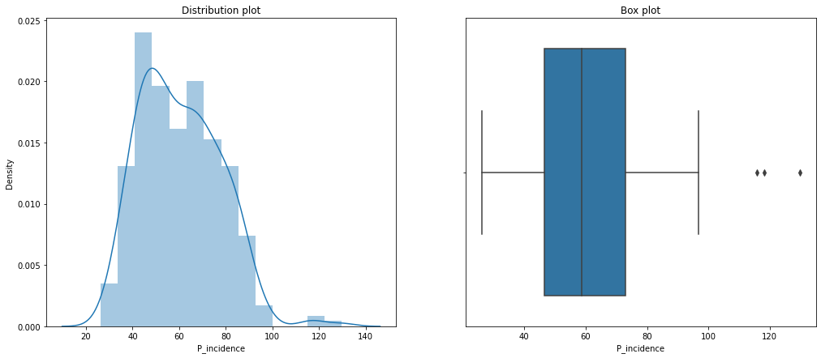

```
Total Number of outliers in P_incidence: 3
```

```python
f,axes = plt.subplots(1,2, figsize=(17,7))
sns.distplot(df['P_incidence'], ax=axes[0])
sns.boxplot(x='P_incidence',data=df,orient='h',ax=axes[1])
axes[0].set_title('Distribution plot')
axes[1].set_title('Box plot')
plt.show()

#Checking count of outliers
q25,q75=np.percentile(df['P_incidence'],25),np.percentile(df['P_incidence'],75)
IQR=q75-q25
Threshold=1.5*IQR
lower,upper=q25-Threshold,q75+Threshold
Outliers=[i for i in df['P_incidence'] if i<lower or i>upper]
print('Total Number of outliers in P_incidence: {}'.format(len(Outliers)))
```

*Data is Normally distributed with very less extreme values*

#### P_tilt

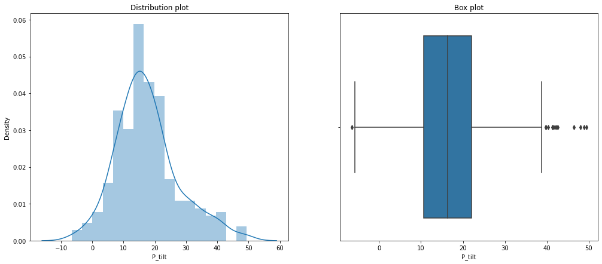

```
Total number of outliers in P_tilt: 13
```

```python
f,axes=plt.subplots(1,2,figsize=(17,7))
sns.distplot(df['P_tilt'],ax=axes[0])
sns.boxplot(x='P_tilt',data=df,orient='h',ax=axes[1])
axes[0].set_title('Distribution plot')
axes[1].set_title('Box plot')
plt.show()

#Checking the count of outliers
q25,q75=np.percentile(df['P_tilt'],25),np.percentile(df['P_tilt'],75)
IQR=q75-q25
Threshold=1.5*IQR
lower,upper=q25-Threshold,q75+Threshold
Outliers=[i for i in df["P_tilt"] if i < lower or i > upper]
print('Total number of outliers in P_tilt: {}'.format(len(Outliers)))
```

*Data is Normally distributed*

*It has little skewness towards right side*

*There is one outlier in the Negative end and few outliers in Positive end*

#### L_angle

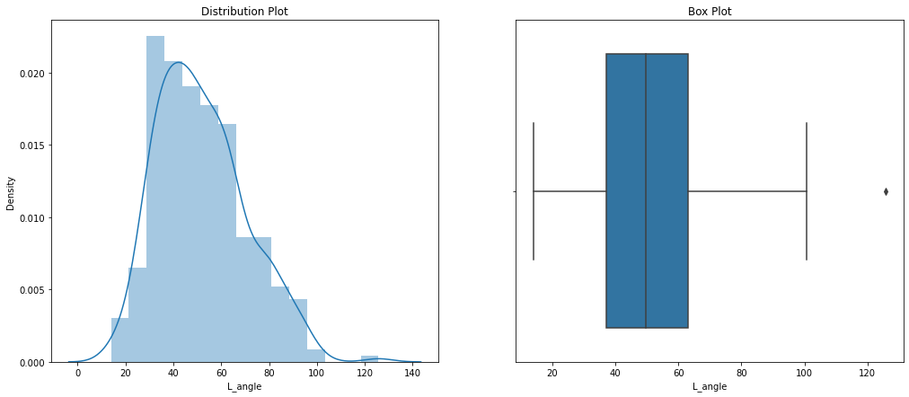

```
Total number of Outliers in L_angle: 1
```

```python
f,axes=plt.subplots(1,2,figsize=(17,7))
sns.distplot(df['L_angle'],ax=axes[0])
sns.boxplot(x='L_angle',data=df,orient='h',ax=axes[1])
axes[0].set_title('Distribution Plot')
axes[1].set_title('Box Plot')
plt.show()

#Checking count of outliers
q25,q75=np.percentile(df['L_angle'],25),np.percentile(df['L_angle'],75)
IQR=q75-q25
Threshold=1.5*IQR
upper,lower=q75+Threshold,q25-Threshold
Outliers=[i for i in df['L_angle'] if i<lower or i>upper]
print('Total number of Outliers in L_angle: {}'.format(len(Outliers)))
```

*Data is normally distributed with little right skewness*

*There is 1 outlier*

#### S_slope

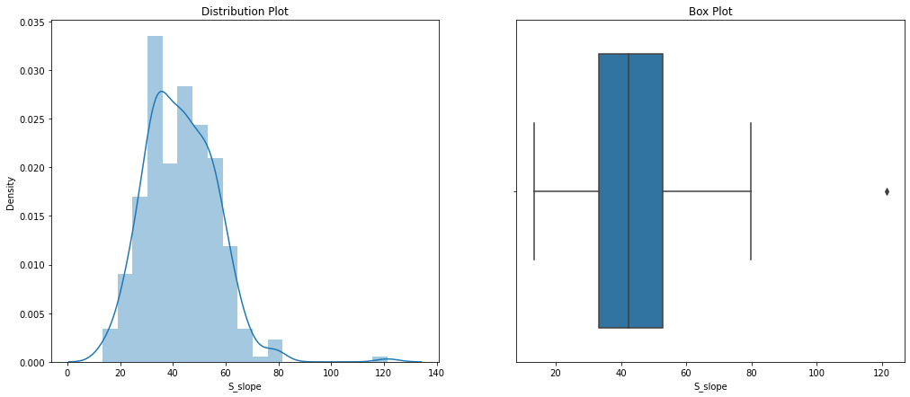

```
Total number of Outliers in S_slope: 1
```

```python
f,axes=plt.subplots(1,2,figsize=(17,7))
sns.distplot(df['S_slope'],ax=axes[0])
sns.boxplot(x='S_slope',data=df,orient='h',ax=axes[1])
axes[0].set_title('Distribution Plot')
axes[1].set_title('Box Plot')
plt.show()

#Checking count of outliers
q25,q75=np.percentile(df['S_slope'],25),np.percentile(df['S_slope'],75)
IQR=q75-q25
Threshold=1.5*IQR
upper,lower=q75+Threshold,q25-Threshold
Outliers=[i for i in df['S_slope'] if i<lower or i>upper]
print('Total number of Outliers in S_slope: {}'.format(len(Outliers)))
```

*Data is almost Normally distributed with little right skewness because of one outlier*

#### P_radius

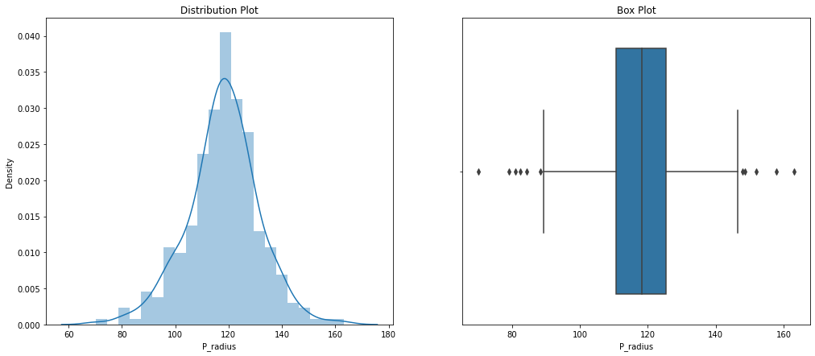

```
Total number of Outliers in P_radius : 11
```

```python
f,axes=plt.subplots(1,2,figsize=(17,7))
sns.distplot(df['P_radius'],ax=axes[0])
sns.boxplot(x='P_radius',data=df,orient='h',ax=axes[1])
axes[0].set_title('Distribution Plot')
axes[1].set_title('Box Plot')
plt.show()

#Checking count of outliers
q25,q75=np.percentile(df['P_radius'],25),np.percentile(df['P_radius'],75)
IQR=q75-q25
Threshold=1.5*IQR
upper,lower=q75+Threshold,q25-Threshold
Outliers=[i for i in df['P_radius'] if i<lower or i>upper]
print('Total number of Outliers in P_radius : {}'.format(len(Outliers)))
```

*Data is Normally distributed with outliers on both the ends*

#### S_Degree

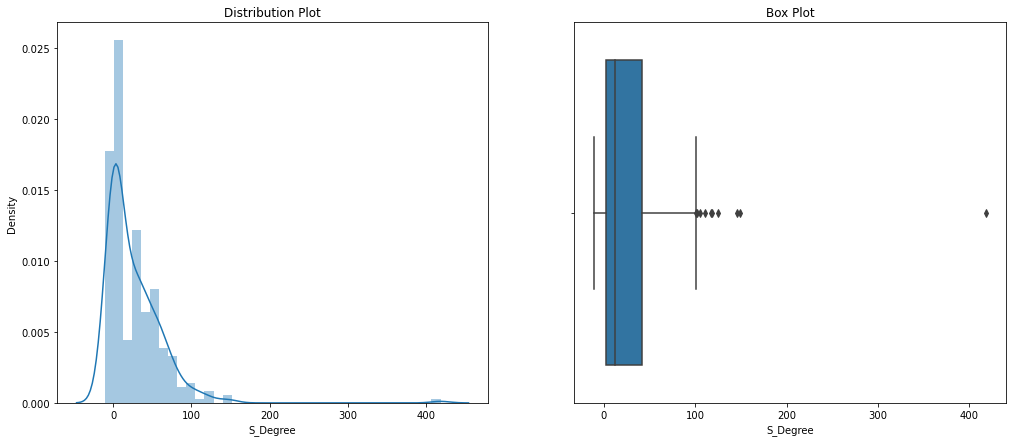

```
Total number of Outliers in S_Degree : 10
```

```python
f,axes=plt.subplots(1,2,figsize=(17,7))
sns.distplot(df['S_Degree'],ax=axes[0])
sns.boxplot(x='S_Degree',data=df,orient='h',ax=axes[1])
axes[0].set_title('Distribution Plot')
axes[1].set_title('Box Plot')
plt.show()

#Checking count of outliers
q25,q75=np.percentile(df['S_Degree'],25),np.percentile(df['S_Degree'],75)
IQR=q75-q25
Threshold=1.5*IQR
upper,lower=q75+Threshold,q25-Threshold
Outliers=[i for i in df['S_Degree'] if i<lower or i>upper]
print('Total number of Outliers in S_Degree : {}'.format(len(Outliers)))
```

*There is Positive Skewness in the data*

*Hugely affected by Outliers*

### Distribution of Target Variable

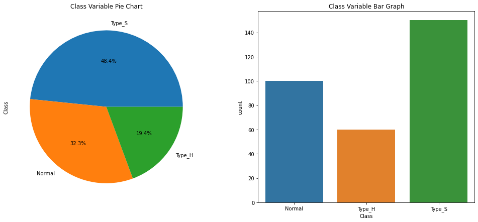

```python
f,axes=plt.subplots(1,2,figsize=(17,7))
df['Class'].value_counts().plot.pie(autopct='%1.1f%%',ax=axes[0])
sns.countplot('Class',data=df,ax=axes[1])
axes[0].set_title('Class Variable Pie Chart')
axes[1].set_title('Class Variable Bar Graph')
plt.show()
```

*Type_S variable has 48.4% of total values followed by Normal and Type_H*

*Data is imbalanced*

## Bi Variate Analysis

#### Target variable vs numerical variables

#### Class vs P_incidence

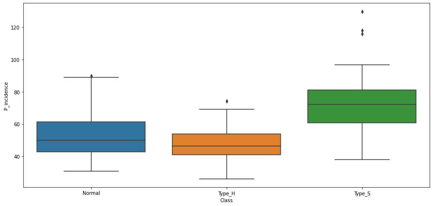

```python
plt.figure(figsize=(15,7))
sns.boxplot(x='Class',y='P_incidence',data=df)
plt.show()
```

*P_Incidence Value is larger for Type_S Class. We can see some extreme values as well*

*Normal Value is slightly higher than Type_H*

#### Class vs P_tilt

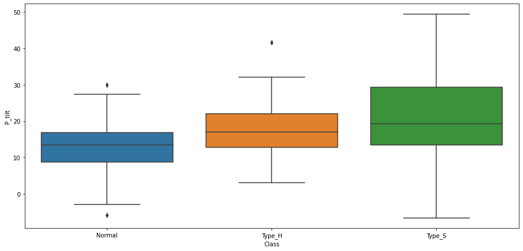

```python
plt.figure(figsize=(15,7))
sns.boxplot(x='Class',y='P_tilt',data=df)
plt.show()
```

*Mean of Type_S is slightly higher than rest two*

*Few cases Normal and Type_H also has huge values*

#### Class vs L_angle

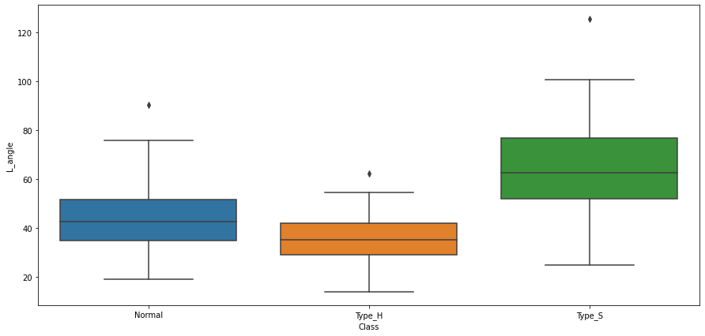

```python
plt.figure(figsize=(15,7))
sns.boxplot(x='Class',y='L_angle',data=df)
plt.show()
```

*L_Angle has higher value for Type_S Class*

*We can see Normal class has higher values compared to type_H class*

*Each class contains one outlier*

#### Class vs S_slope

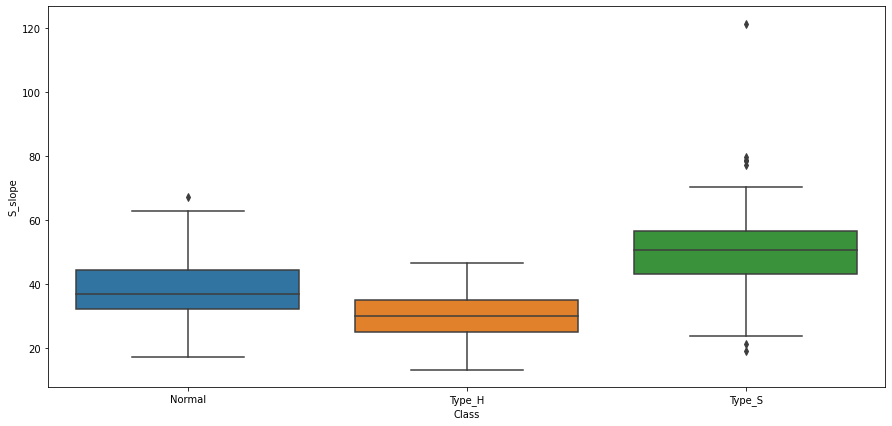

```python
plt.figure(figsize=(15,7))
sns.boxplot(x='Class',y='S_slope',data=df)
plt.show()
```

*S_slope has huge values for Type_S class*

*Normal class has high s_slope compared to Type_H*

#### Class vs P_radius

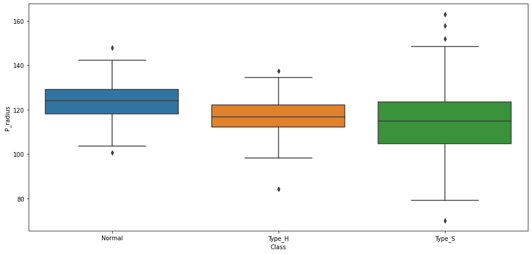

```python
plt.figure(figsize=(15,7))
sns.boxplot(x='Class',y='P_radius',data=df)
plt.show()
```

*P_radius value is more for Normal Class*

*There are some extreme values for Type_s class*

*All classes have positive and negative outlliers*

#### Class vs S_Degree

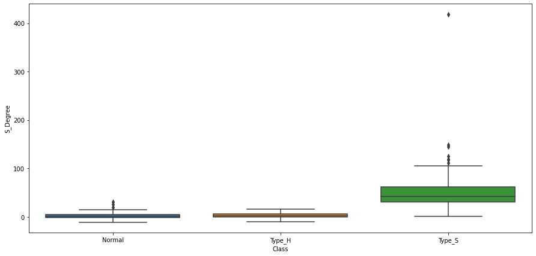

```python
plt.figure(figsize=(15,7))
sns.boxplot(x='Class',y='S_Degree',data=df)
plt.show()
```

*S_Degree has extreme values for type_S Class*

## Multi Variate Analysis

### Pairplot of independent variables

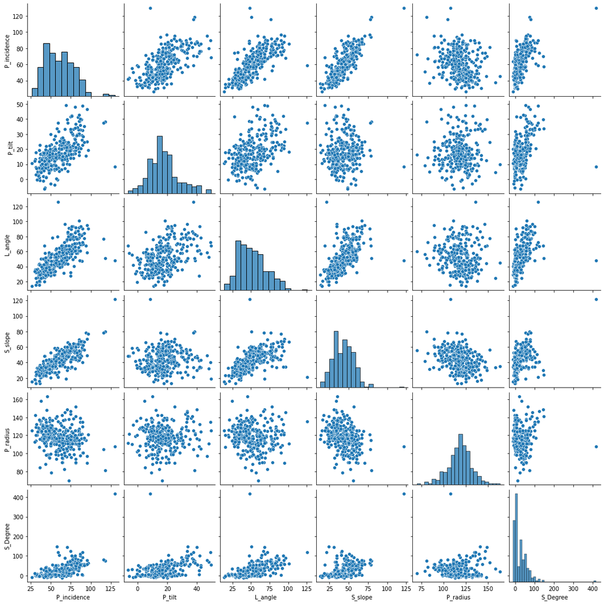

```python
sns.pairplot(df)
plt.show()
```

*Along the diagonal we can see the distribution of individual variable*

*P_incidence has postive relationship with all variables except P_radius. Relationship is higher for S_slope and L_angle*

*P_tilt has some positive Relationship with P_incidence and L_angle.There is no Relationship with S_slope and p_radius*

*L_angle has postive Relationship with P_incidence,P_tilt,S_slope and S_degree. It has no Relationship with P_radius*

*S_slope has positive Relationship with P_incidence,L_angle and s_degree*

*P_radius has no strong positive Relationship with other variables.*

```python
corr = df.corr()
corr.style.background_gradient(cmap='coolwarm')
```

|  | P_incidence | P_tilt | L_angle | S_slope | P_radius | S_Degree |
| --- | --- | --- | --- | --- | --- | --- |
| P_incidence | 1.000000 | 0.629199 | 0.717282 | 0.814960 | -0.247467 | 0.638743 |
| P_tilt | 0.629199 | 1.000000 | 0.432764 | 0.062345 | 0.032668 | 0.397862 |
| L_angle | 0.717282 | 0.432764 | 1.000000 | 0.598387 | -0.080344 | 0.533667 |
| S_slope | 0.814960 | 0.062345 | 0.598387 | 1.000000 | -0.342128 | 0.523557 |
| P_radius | -0.247467 | 0.032668 | -0.080344 | -0.342128 | 1.000000 | -0.026065 |
| S_Degree | 0.638743 | 0.397862 | 0.533667 | 0.523557 | -0.026065 | 1.000000 |

In the correlation matrix we can see that P_incidence and S_slope are highly correlated,therefore we can remove any one of them from the dataset.

Let us select the required features with the hypothesis testing

## Hypothesis Testing

We can statistically check whether all the independent variables has significant effect on target variables

```python
class_summary=df.groupby('Class')
class_summary.mean().reset_index()
```

|  | Class | P_incidence | P_tilt | L_angle | S_slope | P_radius | S_Degree |
| --- | --- | --- | --- | --- | --- | --- | --- |
| 0 | Normal | 51.685244 | 12.821414 | 43.542605 | 38.863830 | 123.890834 | 2.186572 |
| 1 | Type_H | 47.638407 | 17.398795 | 35.463524 | 30.239612 | 116.474968 | 2.480251 |
| 2 | Type_S | 71.514224 | 20.748038 | 64.110108 | 50.766186 | 114.518810 | 51.896687 |

Mean values of Normal and Type_H are almost similar or we can say that the difference between the mean values of Normal and Type_H is low when compared to the difference between Normal vs Type_S and Type_H vs Type_S

*It is clear that S_Degree of Type_S contains larger values.*

### Statistical Testing of continuous feature with target variable

Since there are 3 classes in our Target variable let us use one-way ANOVA test

```python
from scipy import stats
col=['P_incidence','P_tilt','L_angle','S_slope','P_radius','S_Degree']
for i in col:
    print('{} Ho: Class types does not affect the {}'.format('\033[1m',i)) #'\033[1m'- bold letters
    print('\n')
    print('{} H1: Class types affect the {}'.format('\033[1m',i))
    print('\n')
    df_normal=df[df.Class=='Normal'][i]# df[df.Class=='Normal']-returns the entire dataframe where Class=='Normal',
    #df[df.Class=='Normal'][i]-returns only that i-th series from DF
    df_typeH=df[df.Class=='Type_H'][i]
    df_typeS=df[df.Class=='Type_S'][i]
    f_stats,p_value=stats.f_oneway(df_normal,df_typeH,df_typeS)
    print('{} F_stats: {}'.format('\033[1m',f_stats))
    print('{} p_value: {}'.format('\033[1m',p_value))
    if p_value < 0.05:  # Setting our significance level at 5%
        print('{} Rejecting Null Hypothesis.Class types has efect on {}'.format('\033[1m',i))
    else:
        print('{} Fail to Reject Null Hypothesis.Class types has no effect on {}'.format('\033[1m',i))
    print('\n')
```

```
 Ho: Class types does not affect the P_incidence


 H1: Class types affect the P_incidence


 F_stats: 98.53970917437489
 p_value: 8.752848964938295e-34
 Rejecting Null Hypothesis.Class types has efect on P_incidence


 Ho: Class types does not affect the P_tilt


 H1: Class types affect the P_tilt


 F_stats: 21.29919432898912
 p_value: 2.176879152985521e-09
 Rejecting Null Hypothesis.Class types has efect on P_tilt


 Ho: Class types does not affect the L_angle


 H1: Class types affect the L_angle


 F_stats: 114.98284047330316
 p_value: 5.357329394004833e-38
 Rejecting Null Hypothesis.Class types has efect on L_angle


 Ho: Class types does not affect the S_slope


 H1: Class types affect the S_slope


 F_stats: 89.64395329777523
```

[output cut: 9 more lines]

```

 F_stats: 16.86693475538487
 p_value: 1.1219959042394205e-07
 Rejecting Null Hypothesis.Class types has efect on P_radius


 Ho: Class types does not affect the S_Degree


 H1: Class types affect the S_Degree


 F_stats: 119.12288060759808
 p_value: 5.1147320770401214e-39
 Rejecting Null Hypothesis.Class types has efect on S_Degree
```

*We can see class type affects each and every independent variables*

## 4.Data Pre-processing

### Outlier Analysis

Let us impute outliers with mean

```python
for c in col:
    #getting upper lower quartile values
    q25,q75=np.percentile(df[c],25),np.percentile(df[c],75)
    IQR=q75-q25
    Threshold=IQR*1.5
    lower,upper=q25-Threshold,q75+Threshold
    Outliers=[i for i in df[c] if i < lower or i > upper]
    print('{} Total Number of outliers in {} Before Imputing : {}'.format('\033[1m',c,len(Outliers)))
    print('\n')
    #taking mean of a column without considering outliers
    df_include = df.loc[(df[c] >= lower) & (df[c] <= upper)]
    mean=int(df_include[c].mean())
    print('{} Mean of {} is {}'.format('\033[1m',c,mean))
    print('\n')
    #imputing outliers with mean
    df[c]=np.where(df[c]>upper,mean,df[c])
    df[c]=np.where(df[c]<lower,mean,df[c])
    Outliers=[i for i in df[c] if i < lower or i > upper]
    print('{} Total Number of outliers in {} After Imputing : {}'.format('\033[1m',c,len(Outliers)))
    print('\n')
```

```
 Total Number of outliers in P_incidence Before Imputing : 3


 Mean of P_incidence is 59


 Total Number of outliers in P_incidence After Imputing : 0


 Total Number of outliers in P_tilt Before Imputing : 13


 Mean of P_tilt is 16


 Total Number of outliers in P_tilt After Imputing : 0


 Total Number of outliers in L_angle Before Imputing : 1


 Mean of L_angle is 51


 Total Number of outliers in L_angle After Imputing : 0


 Total Number of outliers in S_slope Before Imputing : 1


 Mean of S_slope is 42


 Total Number of outliers in S_slope After Imputing : 0


 Total Number of outliers in P_radius Before Imputing : 11


 Mean of P_radius is 118


 Total Number of outliers in P_radius After Imputing : 0


 Total Number of outliers in S_Degree Before Imputing : 10


 Mean of S_Degree is 22


 Total Number of outliers in S_Degree After Imputing : 0
```

*We have imputed all outliers with mean value*

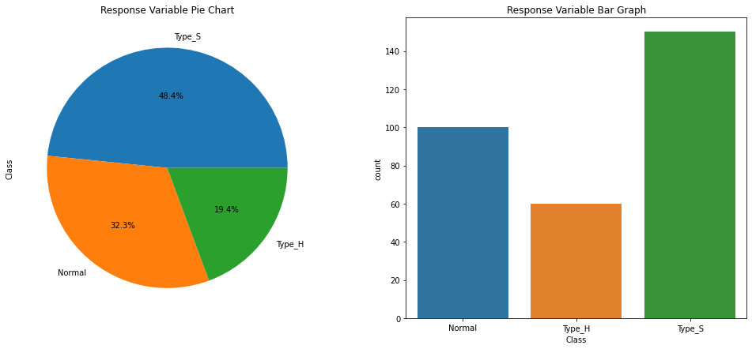

```python
f,axes=plt.subplots(1,2,figsize=(17,7))
df['Class'].value_counts().plot.pie(autopct='%1.1f%%',ax=axes[0])
sns.countplot('Class',data=df,ax=axes[1])
axes[0].set_title('Response Variable Pie Chart')
axes[1].set_title('Response Variable Bar Graph')
plt.show()
```

*We have imbalanced target variable*

*Every class is not equally distributed.*

*48% of data is occupied by Type_S*

*When you have imbalance dataset model does not learn about less distributed classes. This gives poor performance in unseen data*

## Train - Test Split

```python
X=df.drop(labels="Class",axis=1)
y=df['Class']
```

```python
X.shape
```

```
(310, 6)
```

```python
y.shape
```

```
(310,)
```

### Split X and y into training and test set in 70:30 ratio

## 5.Model training, testing and tuning

```python
from sklearn.model_selection import train_test_split
X_train,X_test,y_train,y_test=train_test_split(X,y,test_size=0.30,random_state=10)
```

### Importing the model

```python
from sklearn.neighbors import KNeighborsClassifier
NNH=KNeighborsClassifier(n_neighbors=5,metric='euclidean')
```

### Scaling Test and Train data

```python
from sklearn.preprocessing import StandardScaler
scaler=StandardScaler()
scaler.fit(X_train)
X_train=scaler.transform(X_train)
X_test=scaler.transform(X_test)
```

```python
NNH.fit(X_train,y_train)
```

```
KNeighborsClassifier(metric='euclidean')
```

```python
print('Accuracy on Training data: ',NNH.score(X_train,y_train))
```

```
Accuracy on Training data:  0.880184331797235
```

```python
predicted=NNH.predict(X_test)
print('Accuracy on Test data:',NNH.score(X_test,y_test))
```

```
Accuracy on Test data: 0.8279569892473119
```

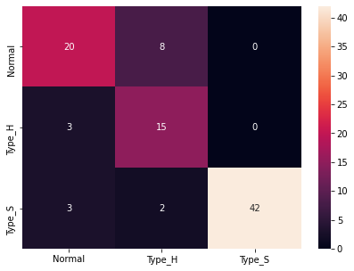

```python
from sklearn.metrics import accuracy_score, confusion_matrix
cm = confusion_matrix(y_test, predicted)

df_cm = pd.DataFrame(cm, index = [i for i in ["Normal","Type_H","Type_S"]],
                  columns = [i for i in ["Normal","Type_H","Type_S"]])
plt.figure(figsize = (7,5))
sns.heatmap(df_cm, annot=True ,fmt='g')
plt.show()
```

*Our model predicts Type_S correctly most of the time. Only five misclassification on this class*

*Misclassification of labels are more when predicting Normal class*

```python
X_train
```

```
array([[ 0.20329845,  0.05094935, -0.15461311,  0.30297511, -0.09424513,
        -0.88395264],
       [ 0.71696919,  0.95123376,  1.56999506,  0.35822361, -0.98189731,
         1.34469731],
       [ 1.5052978 ,  1.52034143,  1.76650754,  1.02221455,  0.78498052,
         1.92929501],
       ...,
       [-0.03378327, -1.01665895,  0.18405256,  0.74229268,  0.6293527 ,
        -0.74293617],
       [-0.37489016,  1.17725474, -0.94669715, -1.28439806,  0.29575014,
        -0.80824284],
       [ 1.42638662,  0.43740418,  1.4138656 ,  1.68707561,  0.65673686,
         1.84916638]])
```

### Classification Report

```python
from sklearn.metrics import classification_report
print("classification  Matrix:\n",classification_report(y_test,predicted))
```

```
classification  Matrix:
               precision    recall  f1-score   support

      Normal       0.77      0.71      0.74        28
      Type_H       0.60      0.83      0.70        18
      Type_S       1.00      0.89      0.94        47

    accuracy                           0.83        93
   macro avg       0.79      0.81      0.79        93
weighted avg       0.85      0.83      0.84        93
```

*class Normal predicted correctly for 77% of time, similarly for class Type_H 60% and for Type_S 100%*

*By F1 score we can say that precision and recall is balanced for class Normal by 74%,similarly for class Type_H by 70% and for Type_S by 94%*

*We have maximum F1 score for class Type_S*

### Finding best K value

```python
# NNH.score(predicted,y_test)
```

```python
train_score=[]
test_score=[]
for k in range(1,51):
    KNN = KNeighborsClassifier(n_neighbors= k , metric = 'euclidean' )
    KNN.fit(X_train, y_train)
    train_score.append(KNN.score(X_train, y_train))
    test_score.append(KNN.score(X_test, y_test))
```

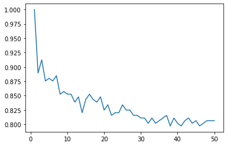

```python
plt.plot(range(1,51),train_score)
plt.show()
```

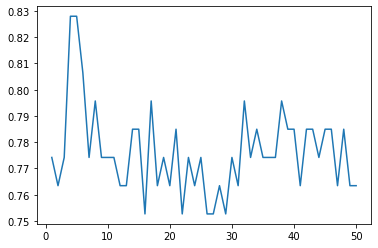

```python
plt.plot(range(1,51),test_score)
plt.show()
```

```python
k=[1,3,5,7,9,11,13,15,17,19]
for i in k:
    KNN = KNeighborsClassifier(n_neighbors=i, metric = 'euclidean' ) #Building knn with 5 neighbors
    KNN.fit(X_train, y_train)
    predicted_labels = KNN.predict(X_test)
    print('Accuracy on Training data for k {} is {}:'.format(i,KNN.score(X_train, y_train)))
    print('Accuracy on Test data for k {} is {}:'.format(i,KNN.score(X_test, y_test)))
    print("classification  Matrix:\n",classification_report(y_test,predicted_labels))
```

```
Accuracy on Training data for k 1 is 1.0:
Accuracy on Test data for k 1 is 0.7741935483870968:
classification  Matrix:
               precision    recall  f1-score   support

      Normal       0.63      0.68      0.66        28
      Type_H       0.55      0.61      0.58        18
      Type_S       0.98      0.89      0.93        47

    accuracy                           0.77        93
   macro avg       0.72      0.73      0.72        93
weighted avg       0.79      0.77      0.78        93

Accuracy on Training data for k 3 is 0.9124423963133641:
Accuracy on Test data for k 3 is 0.7741935483870968:
classification  Matrix:
               precision    recall  f1-score   support

      Normal       0.68      0.54      0.60        28
      Type_H       0.50      0.72      0.59        18
      Type_S       0.98      0.94      0.96        47

    accuracy                           0.77        93
   macro avg       0.72      0.73      0.72        93
weighted avg       0.80      0.77      0.78        93

Accuracy on Training data for k 5 is 0.880184331797235:
Accuracy on Test data for k 5 is 0.8279569892473119:
classification  Matrix:
               precision    recall  f1-score   support

      Normal       0.77      0.71      0.74        28
      Type_H       0.60      0.83      0.70        18
      Type_S       1.00      0.89      0.94        47

    accuracy                           0.83        93
   macro avg       0.79      0.81      0.79        93
weighted avg       0.85      0.83      0.84        93

Accuracy on Training data for k 7 is 0.8847926267281107:
```

[output cut: 74 more lines]

```
   macro avg       0.75      0.76      0.75        93
weighted avg       0.81      0.80      0.80        93

Accuracy on Training data for k 19 is 0.847926267281106:
Accuracy on Test data for k 19 is 0.7741935483870968:
classification  Matrix:
               precision    recall  f1-score   support

      Normal       0.66      0.68      0.67        28
      Type_H       0.57      0.72      0.63        18
      Type_S       0.98      0.85      0.91        47

    accuracy                           0.77        93
   macro avg       0.73      0.75      0.74        93
weighted avg       0.80      0.77      0.78        93
```

*For K=5 we have balanced train and test error*

*we can use k value as 5 because when we increase this value the precision becomes100% for class 2*

## 6.Conclusion and improvisation

All the variables has significant effect on target class

Class belongs to Type_S has higher mean value for almost all variables

Dataset is imbalanced.Suggesting to collect data equally for all the classes.

For almost all variables the distribution is normal

For Knn, k=5 we are getting balanced train and test error